Eat 4 Life Marketing · AI Marketing Made Easy

# AI Search Visibility Report — Royal Oak Dental Group

Cary, NC · Dental · October 2026 · baseline audit

0of 28 AI answers  
name Royal Oak Dental Group

We asked **ChatGPT, Gemini, and Claude** the 7 questions your customers actually type when they're ready to buy — fresh sessions, no history, just like a real person. When customers ask AI who to call, **Royal Oak Dental Group is not in the answer yet** — competitors are. *Perplexity could not be captured this run, so 7 of the 28 answers counted above are untested rather than misses — it re-tests next cycle.*

## Platform by platform

ChatGPT

0/7

Answered 7 of 7 questions and never mentioned Royal Oak Dental Group.

Gemini

0/7

Answered 7 of 7 questions and never mentioned Royal Oak Dental Group.

Perplexity

—

Could not be tested this run — it limits automated logged-out questions. It re-tests next cycle.

Claude

0/7

Answered 7 of 7 questions and never mentioned Royal Oak Dental Group.

## Question by question

| What your customers ask AI | ChatGPT | Gemini | Perplexity | Claude |
| --- | --- | --- | --- | --- |
| best dentist in Cary, NC | — | — | ✗ | — |
| emergency dentist near Cary, NC | — | — | ✗ | — |
| Cary, NC dentist good with anxious patients | — | — | ✗ | — |
| invisalign Cary, NC | — | — | ✗ | — |
| best cosmetic dentist Cary, NC | — | — | ✗ | — |
| dentist taking new patients Cary, NC | — | — | ✗ | — |
| pediatric dentist near Cary, NC | — | — | ✗ | — |

✓ Royal Oak Dental Group named · — answered, not named · ✗ not tested this run

## Who AI recommends instead

Across all answers this month, these businesses were named — each mention is a customer conversation happening without you:

- **Cary Family Dental** — named 6×
- **Signature Smiles** — named 5×
- **Stanley Dentistry** — named 5×
- **Kildaire Family & Cosmetic Dentistry** — named 5×
- **Alliance Dentistry** — named 5×
- **Zen Triangle Dentistry** — named 4×
- **Parkside Family Dental** — named 3×
- **Preston Dental Loft** — named 3×

## The receipts

Exactly what the AI said, captured the moment we asked:

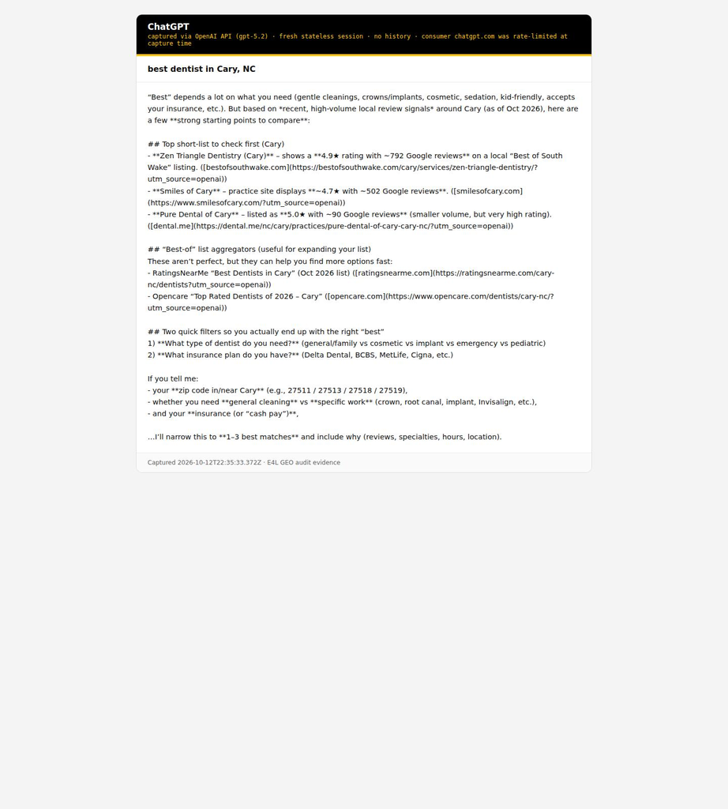

ChatGPT — “best dentist in Cary, NC” — others are recommended; Royal Oak Dental Group is absent.

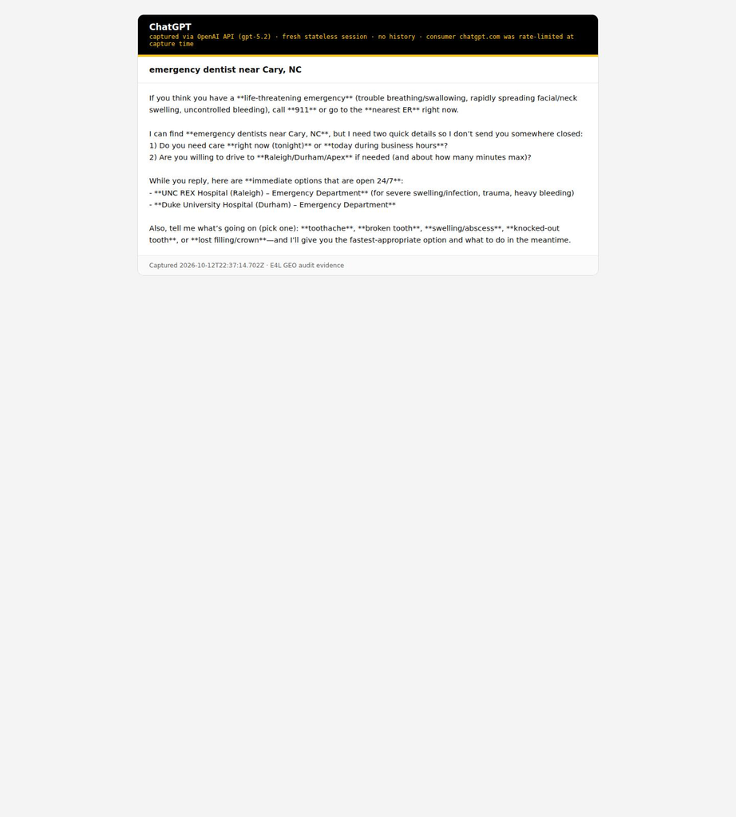

ChatGPT — “emergency dentist near Cary, NC” — others are recommended; Royal Oak Dental Group is absent.

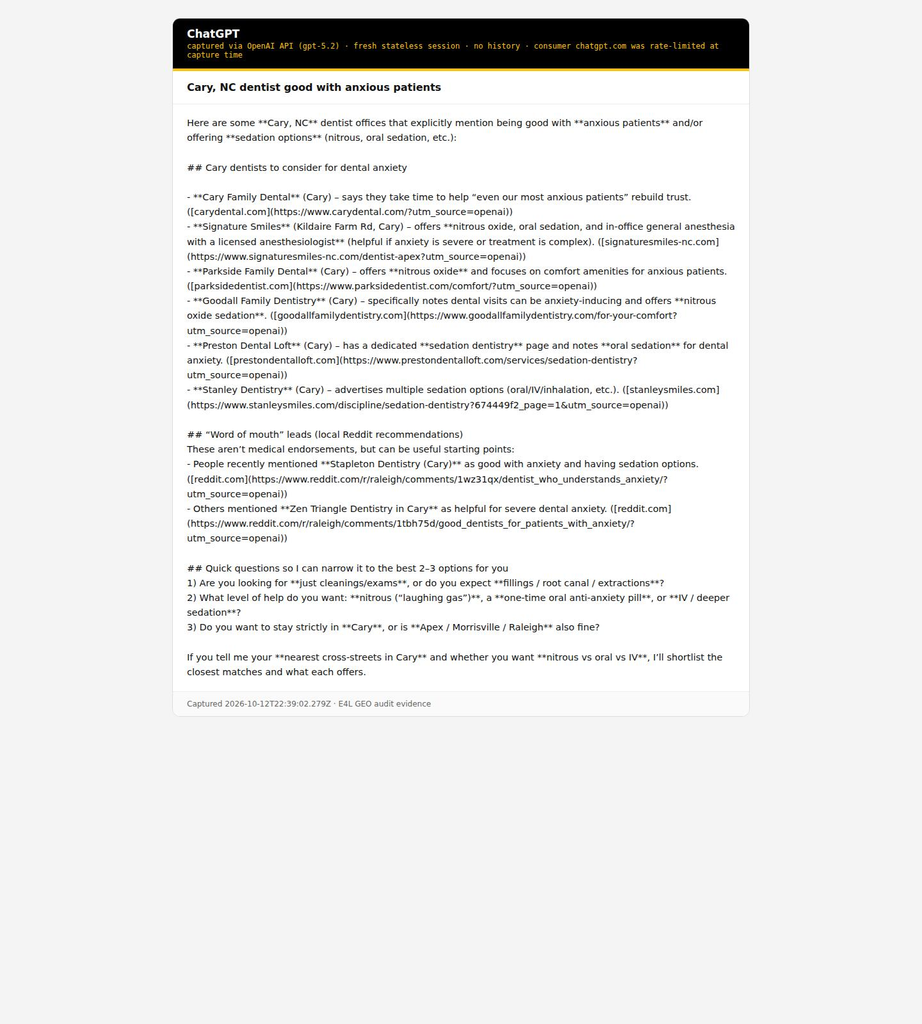

ChatGPT — “Cary, NC dentist good with anxious patients” — others are recommended; Royal Oak Dental Group is absent.

[figure not shown]

ChatGPT — “best cosmetic dentist Cary, NC” — others are recommended; Royal Oak Dental Group is absent.

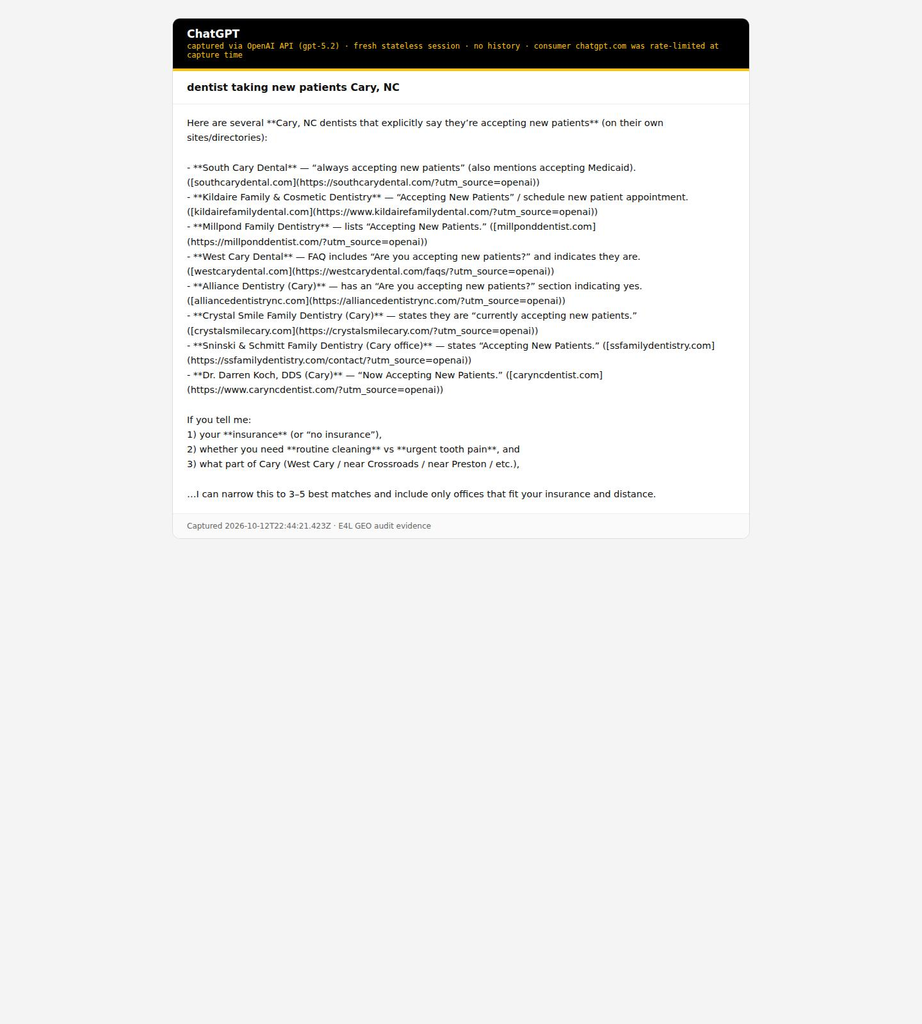

ChatGPT — “dentist taking new patients Cary, NC” — others are recommended; Royal Oak Dental Group is absent.

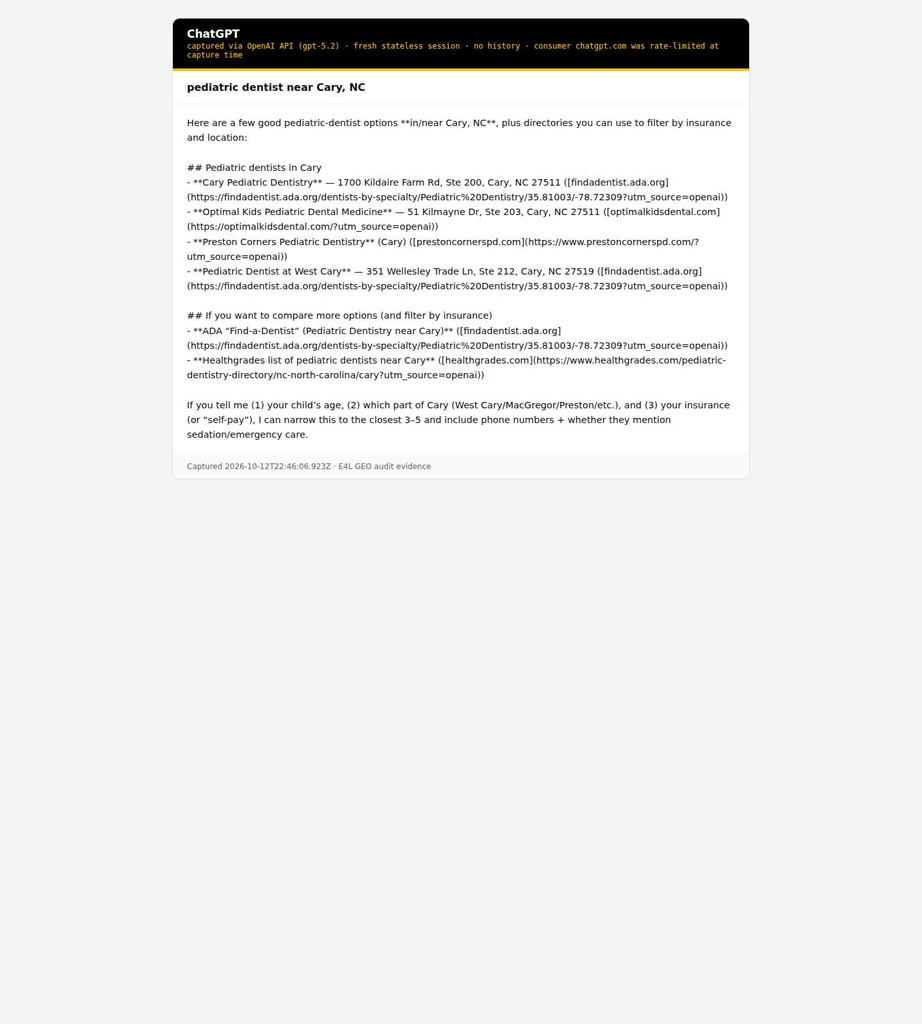

ChatGPT — “pediatric dentist near Cary, NC” — others are recommended; Royal Oak Dental Group is absent.

## Dashboard line

**AI VISIBILITY — October 2026. Baseline: named in 0/28 AI answers. This month: named in 0/28. Screenshots attached. Next: re-test Perplexity once its limit resets.**